# R Notebook

1. In lecture, we used maximum likelihood and a likelihood ratio test to complete a t-test. We can actually use a likelihood ratio test to compare two models as long as one model is a subset of the other model. For example, we can ask whether y is a hump-shaped vs. linear function of x by comparing a quadratic (a + bx + cx^2) vs. linear (a + bx) model. Generate a script that evaluates which model is more appropriate for the data in data.txt.

```r
data2 = read.table("Ex10data.csv", sep =",", header = TRUE )
head(data2)
```

|  | x | y |
| --- | --- | --- |
| 1 | 10.791658 | 62.81551 |
| 2 | 48.218095 | 234.05926 |
| 3 | 9.301926 | 108.15217 |
| 4 | 9.821652 | 63.34939 |
| 5 | 30.092501 | 154.81366 |
| 6 | 41.506028 | 202.79114 |

```r
nllike<-function(p,x,y){ #liklihood function for linear equation
  B0=p[1]
  B1=p[2]
  sigma=exp(p[3])
  expected=B0+B1*x
  nll=-sum(dnorm(x=y,mean=expected,sd=sigma,log=TRUE))
  return(nll)
}
initialGuess=c(1,1,1) #a spot to start
fit=optim(par=initialGuess,fn=nllike,x=data2$x,y=data2$y)
print(fit)
```

```
$`par`
[1] 16.993438  4.481469  2.888480

$value
[1] 107.7382

$counts
function gradient
     242       NA

$convergence
[1] 0

$message
NULL
```

```r
#Negative log liklihood = 107.7
#Use this function to generate an estimate of the paramaters of best fit for the data and then compare these estimates to coefficient estimates of  a quadradic equation
```

now estimate the parameters for a quadradic model (a + bx + cx^2)

```r
nllike2<-function(p,x,y){ #liklihood function for quadradic equation
  #parameters:
  B0=p[1]
  B1=p[2]
  B2=p[3]
  sigma=exp(p[4])
  #deterministic model:
  expected=B0+B1*x+B2*x^2
  #calculate negative log liklihood:
  nll=-sum(dnorm(x=y,mean=expected,sd=sigma,log=TRUE))
  return(nll)
}
initialGuess2=c(1,1,1,1) #a spot to start
fit2=optim(par=initialGuess2,fn=nllike,x=data2$x, x2=(data$x)^2, y=data2$y)
```

```
Error in fn(par, ...) : unused argument (x2 = (data$x)^2)
```

Now calcuate a test statistic using the 2 negative log liklihoods for the 2 models then ask if this test stastic falls within the chisquared ditribution

```r
1-pchisq(teststat,df)
```

[output not shown]

```
[1] 1
```

[figure not shown]

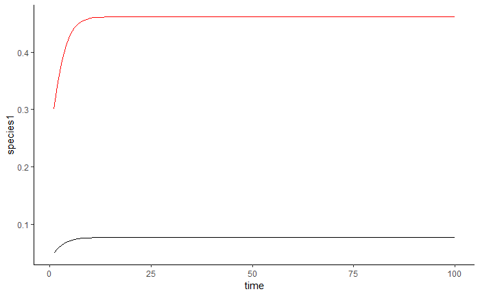

```r
# sim 2
times=1:100
N0=c(0.05,0.3)
params3=c(0.5,10,0.5,0.5,10,0.5)
sim3=ode(y=N0,times=times,func=popmodel,parms=params3)
out3=data.frame(time=sim3[,1],species1=sim3[,2],species2=sim3[,3])
ggplot(out3,aes(x=time,y=species1))+geom_line()+geom_line(data=out3,mapping=aes(x=time,y=species2),col='red')+theme_classic()
```

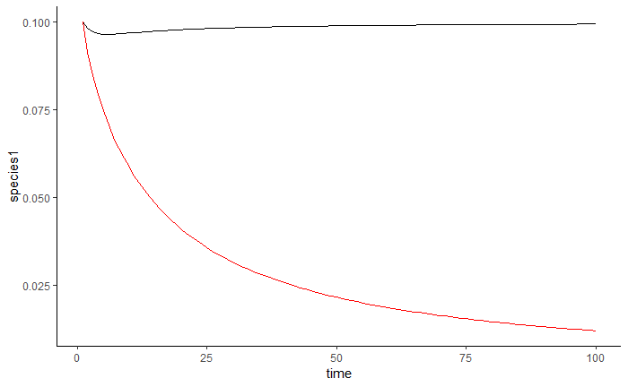

```r
# sim 3
times=1:100
N0=c(0.1,0.1)
params4=c(0.5,10,0.5,0.5,10,2)
sim4=ode(y=N0,times=times,func=popmodel,parms=params4)
out4=data.frame(time=sim4[,1],species1=sim4[,2],species2=sim4[,3])
ggplot(out4,aes(x=time,y=species1))+geom_line()+geom_line(data=out4,mapping=aes(x=time,y=species2),col='red')+theme_classic()
```

Conclusion:

Sim 2: k is greater than alpha for species 1 AND greater than alpha for species 2, therfore coexistence with species 1 and species 2 occurs

Sim3: k is greater than alpha for species 1 and less than alpha for species 2, therfore coexistence does not occur an species one outcompetes species 2